# Parisiens en quête de biodiversité, promenez-vous dans les cimetières!

Eric Marcon, Florence Puech

22 mars 2021

Traitement des données de la base de données ouvertes de la ville de Paris pour le billet *Parisiens en quête de biodiversité, promenez-vous dans les cimetières !* dans [The Conversation](https://theconversation.com/parisiens-en-quete-de-biodiversite-promenez-vous-dans-les-cimetieres-151386).

Ce document est un bloc-note R Markdown: il contient le code R nécessaire à la reproduction de tout le traitement des données, de leur obtention à partir des données ouvertes de la ville de Paris à la production des figures. Le projet peut être copié à partir de GitHub[^1] et exécuté dans RStudio.

# Préparation des données

## Importation

Source des données: https://opendata.paris.fr/explore/dataset/les-arbres/export/

Copie du jeu de données entier au format GeoJSON dans `/data/les-arbres.les-arbres.geojson`. Idem pour le fond de carte des arrondissements de Paris.

```r
# Créer le dossier data
if (!dir.exists("data")) dir.create("data")
# Arbres
if (!file.exists("data/les-arbres.geojson")) # Télécharger le fichier de données s'il n'existe pas (100 Mo)
download.file("https://opendata.paris.fr/explore/dataset/les-arbres/download/?format=geojson",
    destfile = "data/les-arbres.geojson")
# Arrondissements
if (!file.exists("data/arrondissements.geojson")) download.file("https://opendata.arcgis.com/datasets/8463ae61c7ba4388bf08189effcbf2f1_0.geojson",
    destfile = "data/arrondissements.geojson")
```

## Lecture

Le fichier est lu par le package `rgdal`.

```r
library("rgdal")
# Lecture du GeoJSon
les_arbres <- readOGR("data/les-arbres.geojson", "les-arbres", encoding = "UTF-8",
    use_iconv = TRUE)
```

Lecture du fichier des arrondissements.

```r
arrondissements <- readOGR("data/arrondissements.geojson", layer = "COMMUNE_ARRONDISSEMENT_BOIS",
    encoding = "UTF-8", use_iconv = TRUE)
# Filtrage des 20 arrondissements sans les Bois
arrondissements <- arrondissements[arrondissements@data$C_CAINSEE%/%1000 == 75 &
    arrondissements@data$B_BOIS == "N", ]
# Arrondissement décrit par son numéro
library("tidyverse")
```

[figure not shown]

```r
arrondissements@data$L_CAB <- str_replace(arrondissements@data$L_CAB, "er", "")
arrondissements@data$L_CAB <- str_replace(arrondissements@data$L_CAB, "e", "")
arrondissements@data$L_CAB <- str_replace(arrondissements@data$L_CAB, "ème", "")
library("sp")
plot(arrondissements)
```

## Datum

Projection des données dans le référentiel Lambert 93 pour avoir des coordonnées en mètres.

```r
les_arbres_Lambert93 <- les_arbres %>% spTransform(CRS("+init=epsg:2154"))
arrondissements_Lambert93 <- arrondissements %>% spTransform(CRS("+init=epsg:2154"))
```

## Choix des données

Le nombre total d’arbres est 204638.

### Domanialité

```r
library("tidyverse")
les_arbres@data %>%
  group_by(domanialite) %>%
  summarise(Nombre=n()) %>%
  arrange(desc(Nombre))
```

```
## # A tibble: 9 x 2
##   domanialite  Nombre
##   <chr>         <int>
## 1 Alignement   105941
## 2 Jardin        48295
## 3 CIMETIERE     32174
## 4 DASCO          7136
## 5 PERIPHERIQUE   5291
## 6 DJS            4370
## 7 DFPE           1393
## 8 DAC              27
## 9 DASES            11
```

Traduction des sigles:

```r
data.frame(Sigle = c("DASCO", "DJS", "DFPE", "DAC", "DASES"),
           Signification = c("Ecoles", "Equipements sportifs", "Crèches", "Equipements culturels", "Action sociale")) %>%
  knitr::kable(caption="Domanialité", longtable = TRUE, booktabs = TRUE) %>%
  kableExtra::kable_styling(bootstrap_options = "striped", full_width = FALSE)
```

Domanialité

| Sigle | Signification |
| --- | --- |
| DASCO | Ecoles |
| DJS | Equipements sportifs |
| DFPE | Crèches |
| DAC | Equipements culturels |
| DASES | Action sociale |

Les arbres référencés sont les arbres d’alignement, ceux des jardins, des cimetières, des équipements municipaux (écoles, etc.), du périphérique. Les arbres des bois de Boulogne et Vincennes sont seulement ceux des équipements municipaux. Les parcs non municipaux, comme le Jardin des Tuileries ou celui du Luxembourg, ne sont pas cartographiés.

### Lieu

```r
les_arbres@data %>%
  group_by(arrondissement) %>%
  summarise(Nombre=n()) %>%
  arrange(desc(Nombre))
```

```
## # A tibble: 25 x 2
##    arrondissement    Nombre
##    <chr>              <int>
##  1 PARIS 15E ARRDT    17226
##  2 PARIS 13E ARRDT    16892
##  3 PARIS 16E ARRDT    16794
##  4 PARIS 20E ARRDT    15762
##  5 PARIS 19E ARRDT    14489
##  6 PARIS 12E ARRDT    12612
##  7 SEINE-SAINT-DENIS  11939
##  8 BOIS DE VINCENNES  11831
##  9 PARIS 14E ARRDT    11702
## 10 PARIS 17E ARRDT    10859
## # ... with 15 more rows
```

On gardera donc les données de Paris intra-muros seulement (Arrondissement numéroté) pour éliminer les Bois et la banlieue.

## Extraction

Préparation du jeu de données.

```r
les_arbres@data %>%
  # Ajout des colonnes de coordonnées
  bind_cols(as.data.frame(les_arbres_Lambert93@coords)) %>%
  # Sélection des colonnes
  select(-typeemplacement, -geo_point_2d1, -geo_point_2d2, -complementadresse) %>%
  # Suppression des facteurs avant de manipuler les chaînes de caractères
  mutate(arrondissement=as.character(arrondissement)) %>%
  mutate(adresse=as.character(adresse)) %>%
  # Filtrage des lignes
  dplyr::filter(str_detect(arrondissement, "^PARIS")) %>%
  # Filtrage des lignes : élimination de DAC et DASES (trop marginal)
  dplyr::filter(domanialite!="DAC") %>%
  dplyr::filter(domanialite!="DASES") %>%
  # Ajout d'une colonne Genre espèce
  mutate(spName=paste(genre, espece)) %>%
  # Arrondissement décrit par son numéro
  mutate(arrondissement=str_replace(arrondissement, "PARIS ", "")) %>%
  mutate(arrondissement=str_replace(arrondissement, "E ARRDT", "")) %>%
  mutate(arrondissement=str_replace(arrondissement, "ER ARRDT", "")) %>%
  # Simplification des adresses pour rassembler les données des cimetières
  mutate(adresse=str_trim(ifelse(str_detect(as.character(adresse), "^CIMETIERE "), str_split(as.character(adresse), "/", simplify=TRUE)[, 1], as.character(adresse)))) %>%
  # Adresse unique pour les espaces répartis sur plusieurs arrondissements et de plusieurs domanialités
  mutate(adresse = paste(adresse, arrondissement, domanialite)) ->
  les_arbres_df
```

# Données de l’article

## Espèces

```r
library("entropart")
les_arbres_df %>%
  group_by(spName) %>%
  summarise(Nombre=n(), .groups='drop') %>%
  arrange(desc(Nombre)) ->
  AbdFreqCount
```

Espèces les plus fréquentes :

```r
AbdFreqCount
```

```
## # A tibble: 651 x 2
##    spName                 Nombre
##    <chr>                   <int>
##  1 Platanus x hispanica    33279
##  2 Aesculus hippocastanum  15468
##  3 Sophora japonica        10675
##  4 Tilia tomentosa          6994
##  5 Acer platanoides         4412
##  6 Acer pseudoplatanus      4360
##  7 Aesculus x carnea        3950
##  8 Celtis australis         3578
##  9 Tilia x europaea         3558
## 10 Platanus occidentalis    3171
## # ... with 641 more rows
```

Le nombre total d’espèces est 651. La liste complète est en annexe.

Diagramme rang-abondance des espèces :

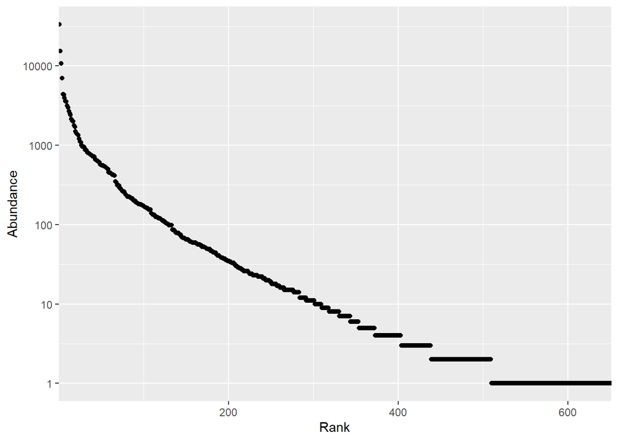

```r
AbdFreqCount %>%
  with(Nombre) %>%
  as.AbdVector %>%
  autoplot
```

## Diversité par domanialité

### Calcul de richesse et Simpson

Calcul de la richesse et de Simpson par adresse.

```r
library("SpatDiv")
```

```r
Entropie <- les_arbres_df %>% group_by(domanialite, arrondissement, adresse) %>%
    summarise(Nombre = n(), Richesse = Richness(spName, Correction = "None"), Simpson = Simpson(spName,
        Correction = "None"), .groups = "drop") %>% arrange(desc(Richesse))
# Recodage des domanialités pour les figures
type_espace <- recode(Entropie$domanialite, Alignement = "Alignements", Jardin = "Jardins",
    CIMETIERE = "Cimetières", PERIPHERIQUE = "Périphérique")
Entropie <- cbind(Entropie, type_espace)
```

### Richesse par domanialité

```r
Entropie %>%
  group_by(domanialite) %>%
  summarise(Nombre = n(),
            Médiane = median(Richesse),
            EcartType = sd(Richesse,),
            .groups='drop')
```

```
## # A tibble: 7 x 4
##   domanialite  Nombre Médiane EcartType
##   <chr>         <int>   <dbl>     <dbl>
## 1 Alignement     2040       2      2.58
## 2 CIMETIERE        16      15     35.3
## 3 DASCO           674       3      3.16
## 4 DFPE            247       2      2.56
## 5 DJS             103       5     10.3
## 6 Jardin          760       5     19.3
## 7 PERIPHERIQUE    210       4      5.16
```

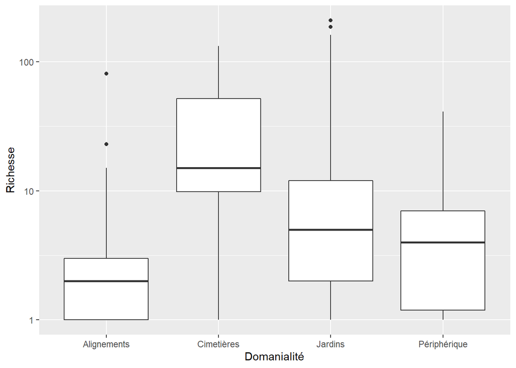

```r
Entropie %>%
  dplyr::filter(domanialite %in% c("Alignement", "CIMETIERE", "Jardin", "PERIPHERIQUE")) %>%
  ggplot(aes(x=type_espace, y=Richesse)) +
  geom_boxplot() +
  scale_y_continuous(trans = "log10") +
  xlab("Domanialité")
```

### Simpson par domanialité

```r
Entropie %>%
  group_by(domanialite) %>%
  summarise(Nombre = n(),
            Médiane = median(Simpson),
            EcartType = sd(Simpson),
            .groups='drop')
```

```
## # A tibble: 7 x 4
##   domanialite  Nombre Médiane EcartType
##   <chr>         <int>   <dbl>     <dbl>
## 1 Alignement     2040  0.0583     0.254
## 2 CIMETIERE        16  0.779      0.289
## 3 DASCO           674  0.58       0.277
## 4 DFPE            247  0.5        0.331
## 5 DJS             103  0.72       0.328
## 6 Jardin          760  0.642      0.330
## 7 PERIPHERIQUE    210  0.536      0.322
```

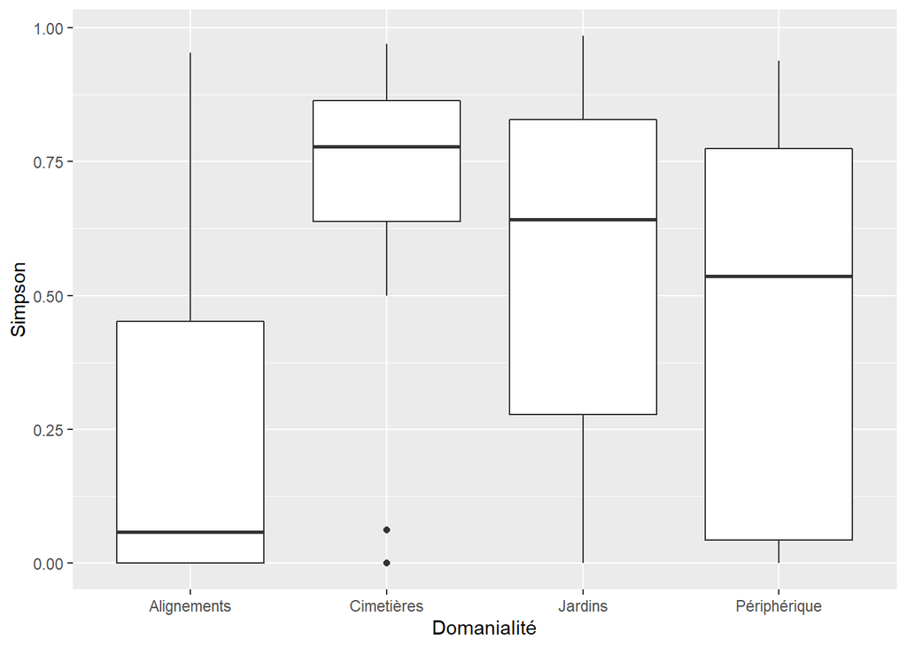

```r
Entropie %>%
  dplyr::filter(domanialite %in% c("Alignement", "CIMETIERE", "Jardin", "PERIPHERIQUE")) %>%
  ggplot(aes(x=type_espace, y=Simpson)) +
  geom_boxplot() +
  xlab("Domanialité")
```

### Diversité par arrondissement

Diversité des arrondissements 8, 11 et 16:

```r
les_arbres_df %>% group_by(arrondissement, adresse) %>% summarise(NumberofTrees = n(),
    Entropy0 = Tsallis(spName, q = 0, Correction = "None"), Entropy2 = Tsallis(spName,
        q = 2, Correction = "None"), .groups = "drop") %>% group_by(arrondissement) %>%
    summarise(nAdresses = n(), alphaRichness = weighted.mean(Entropy0, NumberofTrees),
        alphaSimpson = weighted.mean(Entropy2, NumberofTrees), .groups = "drop") %>%
    dplyr::filter(arrondissement %in% c("8", "11", "16"))
```

```
## # A tibble: 3 x 4
##   arrondissement nAdresses alphaRichness alphaSimpson
##   <chr>              <int>         <dbl>        <dbl>
## 1 11                   183          5.88        0.465
## 2 16                   273         23.3         0.471
## 3 8                     91         15.5         0.385
```

Pour Paris entier (intra muros):

```r
les_arbres_df %>% summarise(NumberofTrees = n(), Richness = Tsallis(spName, q = 0,
    Correction = "None"), Simpson = Tsallis(spName, q = 2, Correction = "None"))
```

```
##   NumberofTrees Richness   Simpson
## 1        163677      650 0.9373266
```

## Diversités $\alpha$ et $\beta$

### Diversité $\alpha$ des parcs

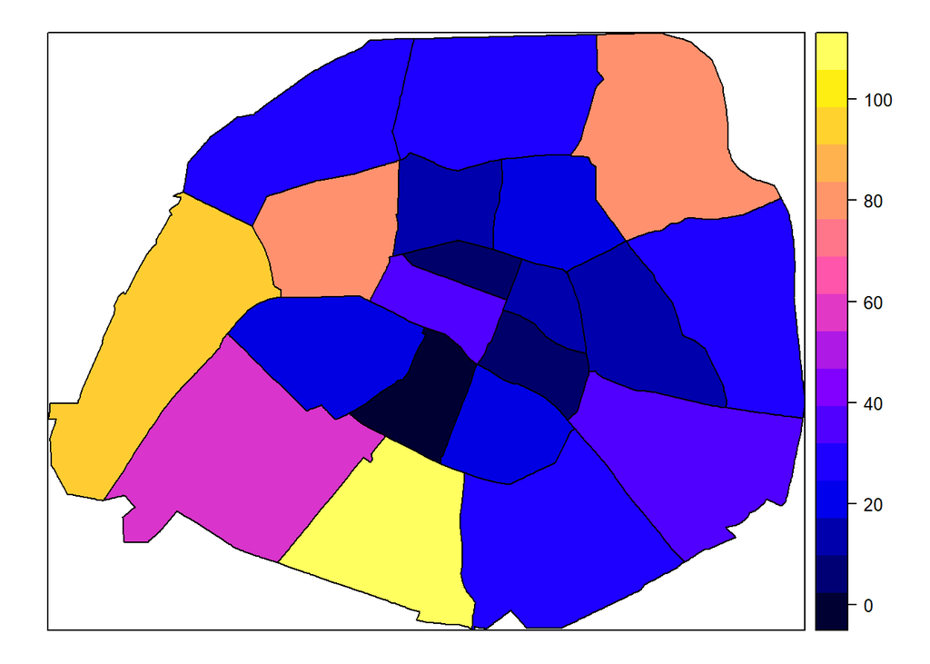

```r
# Alpha
PGDiversite <- les_arbres_df %>% dplyr::filter(domanialite == "Jardin") %>% group_by(arrondissement,
    adresse) %>% summarise(NumberofTrees = n(), Entropy0 = Tsallis(spName, q = 0,
    Correction = "None"), .groups = "drop") %>% group_by(arrondissement) %>% summarise(NumberOfGardens = n(),
    alphaRichness = expq(weighted.mean(Entropy0, NumberofTrees), q = 0), .groups = "drop")
# Plot
merge(arrondissements_Lambert93, PGDiversite, by.x = "L_CAB", by.y = "arrondissement") %>%
    spplot(zcol = "alphaRichness") %>% suppressWarnings
```

Richesse moyenne des parcs, par arrondissement.

### Diversité $\beta$ des parcs

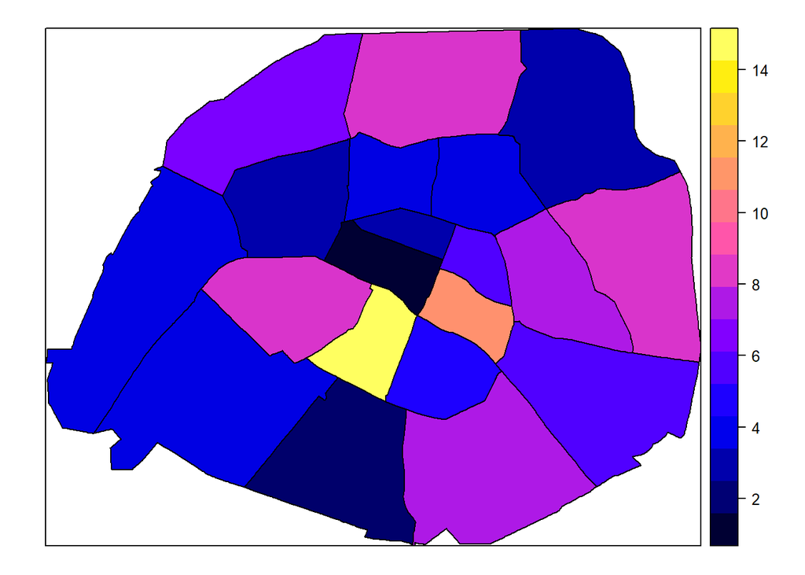

```r
# Gamma
PGDiversite <- les_arbres_df %>% dplyr::filter(domanialite == "Jardin") %>% group_by(arrondissement) %>%
    summarise(NumberOfTrees = n(), gammaRichness = Richness(spName, Correction = "None"),
        .groups = "drop") %>% merge(PGDiversite) %>% mutate(betaRichness = gammaRichness/alphaRichness)
# Plot
merge(arrondissements_Lambert93, PGDiversite, by.x = "L_CAB", by.y = "arrondissement") %>%
    spplot(zcol = "betaRichness")
```

Richesse totale divisée par la richesse moyenne des parcs, par arrondissement.

### Décomposition de la diversité

Richesse des parcs des 16ème et 20ème arrondissements:

```r
PGDiversite[PGDiversite$arrondissement %in% c("16", "20"), c("arrondissement", "alphaRichness",
    "betaRichness", "gammaRichness")]
```

```
##    arrondissement alphaRichness betaRichness gammaRichness
## 8              16      91.32718     3.854274           352
## 13             20      25.77289     8.691302           224
```

# Annexe : liste complète des espèces

```r
knitr::kable(AbdFreqCount[order(AbdFreqCount$spName), ], longtable = TRUE, booktabs = TRUE) %>%
    kableExtra::kable_styling(bootstrap_options = "striped", full_width = FALSE)
```

| spName | Nombre |
| --- | --- |
| Abelia n. sp. | 1 |
| Abelia triflora | 1 |
| Abies alba | 1 |
| Abies bracteata | 26 |
| Abies concolor | 11 |
| Abies n. sp. | 14 |
| Abies nordmanniana | 5 |
| Abies numidica | 2 |
| Abies pinsapo | 16 |
| Acacia dealbata | 14 |
| Acacia n. sp. | 1 |
| Acacia NA | 2 |
| Acca sellowiana | 2 |
| Acer buergerianum | 85 |
| Acer campestre | 1202 |
| Acer capillipes | 12 |
| Acer cappadocicum | 179 |
| Acer carpinifolium | 4 |
| Acer cissifolium | 2 |
| Acer davidii | 59 |
| Acer davidii subsp. grosseri | 3 |
| Acer freemanii | 132 |
| Acer griseum | 22 |
| Acer heldreichii | 1 |
| Acer henryi | 1 |
| Acer japonicum | 12 |
| Acer macrophyllum | 1 |
| Acer monspessulanum | 311 |
| Acer n. sp. | 212 |
| Acer NA | 17 |

[output cut: 621 more lines]

## Espèces indéterminées

Espèces notées “n. sp”:

```r
nsp <- les_arbres_df %>% group_by(genre, espece) %>% summarise(Nombre = n(), .groups = "drop") %>%
    dplyr::filter(espece == "n. sp.")
nsp
```

```
## # A tibble: 84 x 3
##    genre       espece Nombre
##    <chr>       <chr>   <int>
##  1 Abelia      n. sp.      1
##  2 Abies       n. sp.     14
##  3 Acacia      n. sp.      1
##  4 Acer        n. sp.    212
##  5 Aesculus    n. sp.    421
##  6 Ailanthus   n. sp.      1
##  7 Alangium    n. sp.      1
##  8 Albizia     n. sp.      2
##  9 Alnus       n. sp.     31
## 10 Amelanchier n. sp.     53
## # ... with 74 more rows
```

Espèces non renseignées:

```r
nasp <- les_arbres_df %>% group_by(genre, espece) %>% summarise(Nombre = n(), .groups = "drop") %>%
    dplyr::filter(is.na(espece))
nasp
```

```
## # A tibble: 68 x 3
##    genre       espece Nombre
##    <chr>       <chr>   <int>
##  1 Acacia      <NA>        2
##  2 Acer        <NA>       17
##  3 Aesculus    <NA>        5
##  4 Ailanthus   <NA>        2
##  5 Albizia     <NA>        3
##  6 Alnus       <NA>        2
##  7 Amelanchier <NA>       23
##  8 Betula      <NA>        5
##  9 Buxus       <NA>        1
## 10 Carpinus    <NA>        5
## # ... with 58 more rows
```

Espèces doublement notées “n. sp” et NA:

```r
merge(nsp, nasp, by = "genre")
```

```
##            genre espece.x Nombre.x espece.y Nombre.y
## 1         Acacia   n. sp.        1     <NA>        2
## 2           Acer   n. sp.      212     <NA>       17
## 3       Aesculus   n. sp.      421     <NA>        5
## 4      Ailanthus   n. sp.        1     <NA>        2
## 5        Albizia   n. sp.        2     <NA>        3
## 6          Alnus   n. sp.       31     <NA>        2
## 7    Amelanchier   n. sp.       53     <NA>       23
## 8         Betula   n. sp.      191     <NA>        5
## 9          Buxus   n. sp.        2     <NA>        1
## 10      Carpinus   n. sp.        8     <NA>        5
## 11        Cedrus   n. sp.       35     <NA>        3
## 12        Celtis   n. sp.       18     <NA>       33
## 13 Chamaecyparis   n. sp.      109     <NA>        2
## 14        Cornus   n. sp.       33     <NA>        7
```

[output cut: 39 more lines]

[^1]: https://github.com/EricMarcon/TheConversation151386